# ML2 classification project - prediction of diabetes

Edyta Pszczolkowska 435022

06 03 2022

The aim of this project is to predict whether a patient is prone to suffering from diabetes. Given the fact, that diabetes has disastrous health complications, such a model is precious tool for prevention and medical research to discover potential risk factors.

*The following methods will be used: + ridge classification + classification tree + random forest + neural networks

DepVar: Diabetes_binary/Outcome - a two level factor (0 - not prone to diabetes, 1 - prone to diabetes)

Independent variables:

*BINARY

- High Blood Pressure –> HighBP
- High Cholesterol – > HighChol
- Cholesterol check within past five years –> CholCheck
- Smoked at least 100 cigarettes in your entire life? [Note: 5 packs = 100 cigarettes] –> Smoker
- Ever had a stroke. –> Stroke
- Coronary heart disease (CHD) or myocardial infarction (MI) –> HeartDiseaseorAttack
- physical activity in past 30 days - not including job 0 –> PhysActivit
- Consume Fruit 1 or more times per day –> Fruit
- Consume Vegetables 1 or more times per day –> Veggie
- Heavy drinkers (adult men having more than 14 drinks per week and adult women having more than 7 drinks per week) –> HvyAlcoholConsump
- Do you have any kind of health care coverage, including health insurance, prepaid plans such as HMOs, or government plans such as Medicare, or Indian Health Service? –> AnyHealthcare
- Was there a time in the past 12 months when you needed to see a doctor but could not because of cost? –> NoDocbcCost
- Do you have serious difficulty walking or climbing stairs? –> DIFFWALK
- Indicate sex of respondent. –> SEX

*Ordinal variables:

- Grade your general your health in a scale 1-5 ( 1 = excellent 2 = very good 3 = good 4 = fair 5 = poor)
- Education level, scale 1-6 (1 - the most basic educations) –> Education
- Income from all sources, scale 1-8 (1 = less than $10,000 5 = less than $35,000 8 = $75,000 or more): –> Income
- Fourteen-level age category
- Body Mass Index (BMI) –> BMI

*Discrete variables:

- for how many days during the past 30 days was your mental health not good? (1-30) –> MENTHLTH
- for how many days during the past 30 days was your physical health not good? (1-30) –> PHYSHLTH

## Loading packages

```r
library(glmnet)
library(caret)
library(ggplot2)
library(dplyr)
library(neuralnet)
```

```r
diabetes <- read.csv("D:\\Edyta pliki\\DS\\III semestr\\ML2\\diabetes_binary.csv")

nrow(diabetes)
```

```
## [1] 70692
```

```r
table(diabetes$Diabetes_binary)
```

```
##
##     0     1
## 35346 35346
```

```r
head(diabetes$Diabetes_binary, 50)
```

```
##  [1] 0 0 0 0 0 0 0 0 0 0 0 0 0 0 0 0 0 0 0 0 0 0 0 0 0 0 0 0 0 0 0 0 0 0 0 0 0 0
## [39] 0 0 0 0 0 0 0 0 0 0 0 0
```

```r
tail(diabetes$Diabetes_binary, 50)
```

```
##  [1] 1 1 1 1 1 1 1 1 1 1 1 1 1 1 1 1 1 1 1 1 1 1 1 1 1 1 1 1 1 1 1 1 1 1 1 1 1 1
## [39] 1 1 1 1 1 1 1 1 1 1 1 1
```

The initial dataset is balanced.

As the dataset is so huge, I will pick up 6000 records. BUT: as we can see above, the column with dependent variable in the initial dataset is sorted, i.e. first 35346 observations have outcome equal to 0. Therefore I can’t simply take first 5% of observations, as I would get only records with “0” as dependent variable.

So I will choose half from tail and half from head:

```r
diabetes <- rbind(head(diabetes, 3000), tail(diabetes,3000))
table(diabetes$Diabetes_binary)
```

```
##
##    0    1
## 3000 3000
```

I don’t really like the name of the dependent variable, I will change it. But much more important thing is to turn it into factor:

```r
names(diabetes)[names(diabetes) == 'Diabetes_binary'] <- 'Outcome'

diabetes$Outcome <- as.factor(diabetes$Outcome)
```

Checking NAs…:

```r
colSums(is.na(diabetes)) %>%
  sort()
```

```
##              Outcome               HighBP             HighChol
##                    0                    0                    0
##            CholCheck                  BMI               Smoker
##                    0                    0                    0
##               Stroke HeartDiseaseorAttack         PhysActivity
##                    0                    0                    0
##               Fruits              Veggies    HvyAlcoholConsump
##                    0                    0                    0
##        AnyHealthcare          NoDocbcCost              GenHlth
##                    0                    0                    0
##             MentHlth             PhysHlth             DiffWalk
##                    0                    0                    0
##                  Sex                  Age            Education
##                    0                    0                    0
##               Income
##                    0
```

Turning all binary variables into factors and leveling ordinal ones:

```r
diabetes$HighBP <- as.factor(diabetes$HighBP)
diabetes$HighChol <- as.factor(diabetes$HighChol)
diabetes$CholCheck <- as.factor(diabetes$CholCheck)
diabetes$Smoker <- as.factor(diabetes$Smoker)
diabetes$Stroke <- as.factor(diabetes$Stroke)
diabetes$HeartDiseaseorAttack <- as.factor(diabetes$HeartDiseaseorAttack)
diabetes$PhysActivity <- as.factor(diabetes$PhysActivity)
diabetes$Fruits <- as.factor(diabetes$Fruits)
diabetes$Veggies <- as.factor(diabetes$Veggies)
diabetes$HvyAlcoholConsump <- as.factor(diabetes$HvyAlcoholConsump)
diabetes$AnyHealthcare <- as.factor(diabetes$AnyHealthcare)
diabetes$NoDocbcCost <- as.factor(diabetes$NoDocbcCost)
diabetes$DiffWalk <- as.factor(diabetes$DiffWalk)
diabetes$Sex <- as.factor(diabetes$Sex)





diabetes$GenHlth <- factor(diabetes$GenHlth,
                           levels = c('5','4','3','2','1'),
                           ordered = TRUE) # !!!    1 - excellent, 5 - very poor
levels(diabetes$GenHlth)
```

```
## [1] "5" "4" "3" "2" "1"
```

```r
diabetes$Education <- factor(diabetes$Education,
                           # levels from lowest to highest
                           levels = c('1','2','3','4','5', '6'),
                           ordered = TRUE) # ordinal
levels(diabetes$Education)
```

```
## [1] "1" "2" "3" "4" "5" "6"
```

```r
diabetes$Income <- factor(diabetes$Income,
                           # levels from lowest to highest
                           levels = c('1','2','3','4','5', '6','7','8'),
                           ordered = TRUE) # ordinal

levels(diabetes$Income)
```

```
## [1] "1" "2" "3" "4" "5" "6" "7" "8"
```

For variable Age there are too many bins, I will assign the records into 4 bins. *As a reminder:

- 1. group = 18-24
- 9. group = 60-64
- …..
- 13. group = 80 or older

*My bins: + young - groups 1,2,3 (18-32) + adult1 - groups 4,5,6 (33-49) + adult2 - groups 7, 8,9 (50-65) + old - groups 10,11,12,13 (66+)

```r
diabetes$Age[diabetes$Age %in% c(1,2,3)] <- "young"
diabetes$Age[diabetes$Age %in% c(4,5,6)] <- "adult1"
diabetes$Age[diabetes$Age %in% c(7,8,9)] <- "adult2"
diabetes$Age[diabetes$Age %in% c(10,11,12,13)] <- "old"

diabetes$Age <- factor(diabetes$Age,
                           # levels from lowest to highest
                           levels = c("young", "adult1", "adult2", "old"  ),
                           ordered = TRUE) # ordinal

levels(diabetes$Age)
```

```
## [1] "young"  "adult1" "adult2" "old"
```

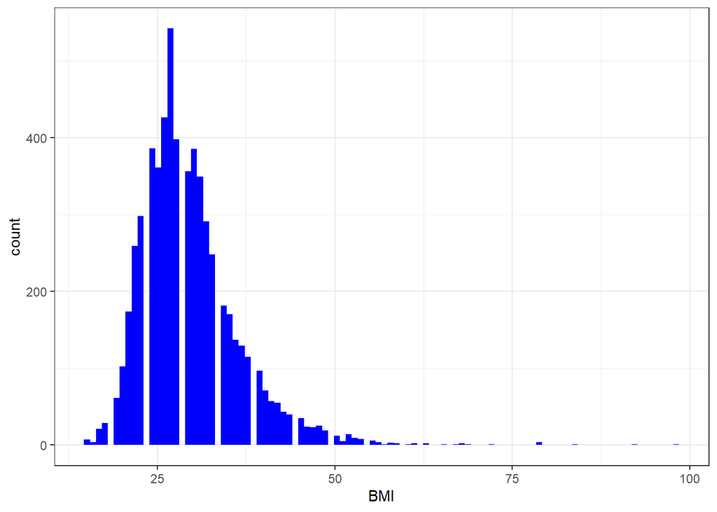

```r
ggplot(diabetes,
       aes(x = BMI)) +
  geom_histogram(fill = "blue",
                 bins = 100) +
  theme_bw()
```

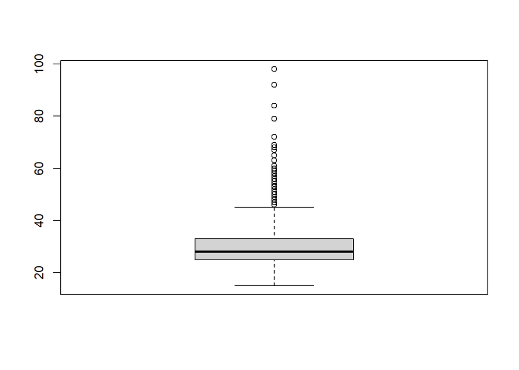

```r
boxplot(diabetes$BMI)
```

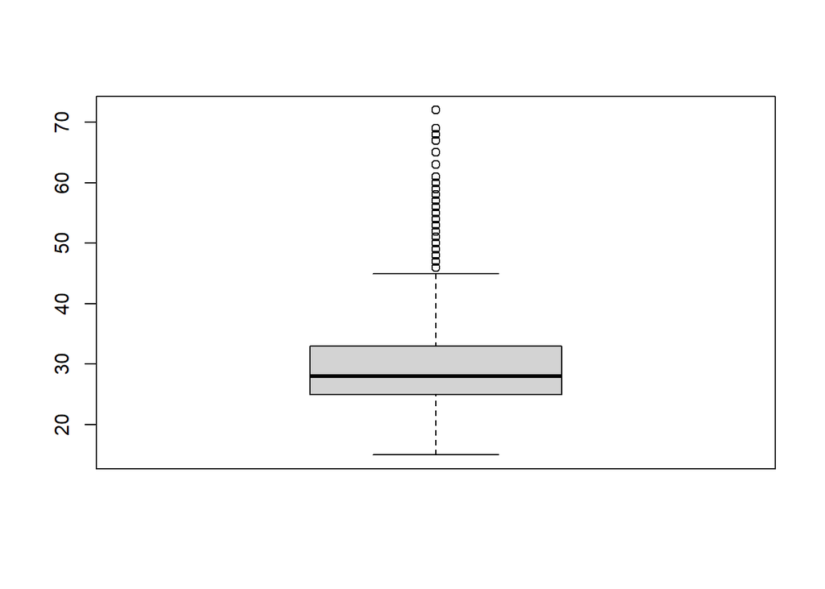

```r
diabetes <- diabetes[diabetes$BMI < 79,]


boxplot(diabetes$BMI)
```

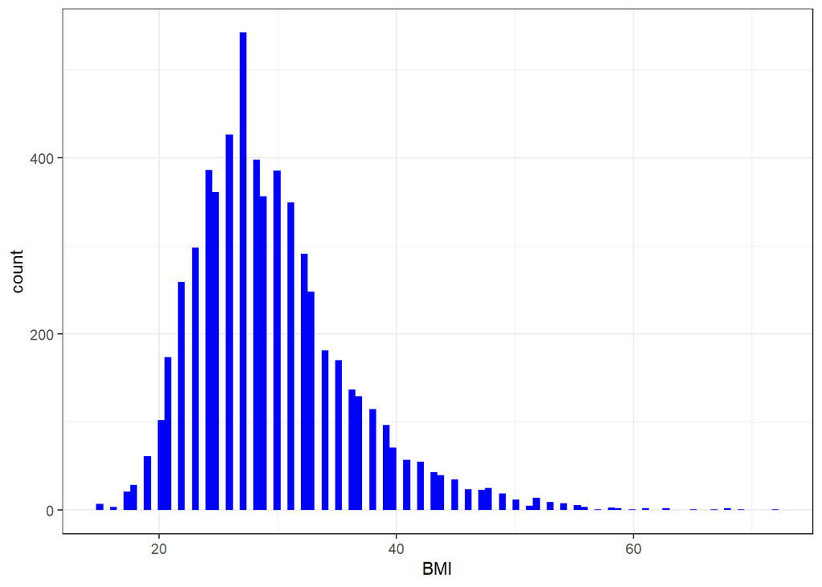

```r
ggplot(diabetes,
       aes(x = BMI)) +
  geom_histogram(fill = "blue",
                 bins = 100) +
  theme_bw()
```

Since there is very common known official table to group this measure, I will bin records in my dataset as well:

```r
diabetes$BMI[diabetes$BMI >= 40] <- "obese III"
diabetes$BMI[diabetes$BMI < 18.5] <- "underweight"
diabetes$BMI[diabetes$BMI >= 18.5 & diabetes$BMI < 24.9  ] <- "normal"
diabetes$BMI[diabetes$BMI >=  25 &  diabetes$BMI < 29.9 ] <- "overweight"
diabetes$BMI[diabetes$BMI >= 30 & diabetes$BMI < 34.9 ] <- "obese I"
diabetes$BMI[diabetes$BMI >=  35 & diabetes$BMI < 39.9 ] <- "obese II"



diabetes$BMI <- factor(diabetes$BMI,
                           # levels from lowest to highest
                           levels = c('underweight','normal','overweight','obese I','obese II', 'obese III'),
                           ordered = TRUE) # ordinal
levels(diabetes$BMI)
```

```
## [1] "underweight" "normal"      "overweight"  "obese I"     "obese II"
## [6] "obese III"
```

```r
table(diabetes$BMI)
```

```
##
## underweight      normal  overweight     obese I    obese II   obese III
##          61        1280        2083        1454         648         467
```

Looks much better.

The next MentHlth and PhysHlth are highly skewed:

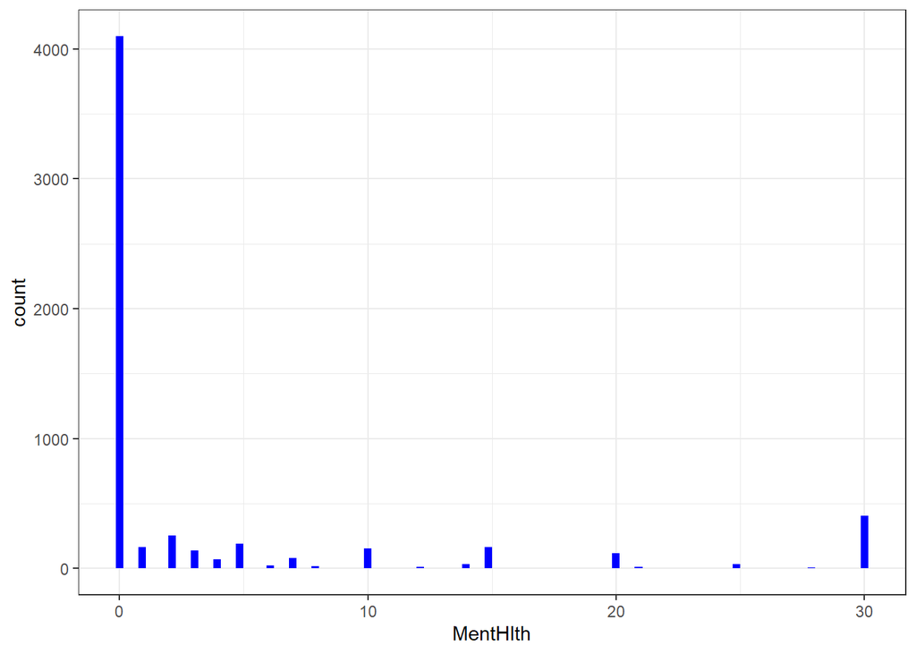

```r
ggplot(diabetes,
       aes(x = MentHlth)) +
  geom_histogram(fill = "blue",
                 bins = 100) +
  theme_bw()
```

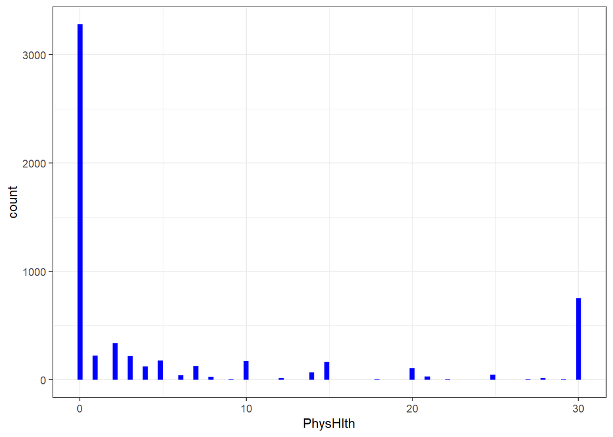

```r
ggplot(diabetes,
       aes(x = PhysHlth)) +
  geom_histogram(fill = "blue",
                 bins = 100) +
  theme_bw()
```

So it needs binning:

```r
diabetes$MentHlth <-
 ( ifelse(diabetes$MentHlth <= 10 , '3',  #good health
       ifelse(diabetes$MentHlth <= 20 , '2',  #moderate health
              '1'))) #poor health"



diabetes$MentHlth <- factor(diabetes$MentHlth,
                           # levels from lowest to highest
                           levels = c('1','2','3'),
                           ordered = TRUE) # ordinal
levels(diabetes$MentHlth)
```

```
## [1] "1" "2" "3"
```

```r
table(diabetes$MentHlth)
```

```
##
##    1    2    3
##  465  335 5193
```

```r
diabetes$PhysHlth <-
  (ifelse(diabetes$PhysHlth <= 10 , '3',  #good health
       ifelse(diabetes$PhysHlth <= 20 , '2',  #moderate health
              '1'))) #poor health"



diabetes$PhysHlth <- factor(diabetes$PhysHlth,
                           # levels from lowest to highest
                           levels = c('1','2','3'),
                           ordered = TRUE) # ordinal
levels(diabetes$PhysHlth)
```

```
## [1] "1" "2" "3"
```

```r
table(diabetes$PhysHlth)
```

```
##
##    1    2    3
##  875  376 4742
```

Checking whether all variables are in an appropriate form:

```r
summary(diabetes)
```

```
##  Outcome  HighBP   HighChol CholCheck          BMI       Smoker   Stroke
##  0:2993   0:2615   0:2870   0: 138    underweight:  61   0:3224   0:5656
##  1:3000   1:3378   1:3123   1:5855    normal     :1280   1:2769   1: 337
##                                       overweight :2083
##                                       obese I    :1454
##                                       obese II   : 648
##                                       obese III  : 467
##
##  HeartDiseaseorAttack PhysActivity Fruits   Veggies  HvyAlcoholConsump
##  0:5087               0:1836       0:2357   0:1221   0:5742
##  1: 906               1:4157       1:3636   1:4772   1: 251
##
##
##
##
##
##  AnyHealthcare NoDocbcCost GenHlth  MentHlth PhysHlth DiffWalk Sex
##  0: 252        0:5397      5: 508   1: 465   1: 875   0:4391   0:3208
##  1:5741        1: 596      4:1338   2: 335   2: 376   1:1602   1:2785
##                            3:1887   3:5193   3:4742
##                            2:1581
##                            1: 679
##
##
##      Age       Education     Income
##  young : 358   1:   5    8      :1608
##  adult1: 940   2: 211    7      : 878
##  adult2:2235   3: 333    6      : 853
##  old   :2460   4:1658    5      : 657
##                5:1687    4      : 555
##                6:2099    3      : 500
##                          (Other): 942
```

```r
glimpse(diabetes)
```

```
## Rows: 5,993
## Columns: 22
## $ Outcome              <fct> 0, 0, 0, 0, 0, 0, 0, 0, 0, 0, 0, 0, 0, 0, 0, 0, 0~
## $ HighBP               <fct> 1, 1, 0, 1, 0, 0, 0, 0, 0, 0, 1, 0, 1, 1, 0, 0, 0~
## $ HighChol             <fct> 0, 1, 0, 1, 0, 0, 1, 0, 0, 0, 1, 0, 1, 0, 1, 0, 0~
## $ CholCheck            <fct> 1, 1, 1, 1, 1, 1, 1, 1, 1, 1, 1, 1, 1, 1, 1, 1, 1~
## $ BMI                  <ord> overweight, overweight, overweight, overweight, o~
## $ Smoker               <fct> 0, 1, 0, 1, 1, 0, 1, 1, 0, 1, 1, 0, 0, 0, 1, 1, 0~
## $ Stroke               <fct> 0, 1, 0, 0, 0, 0, 0, 0, 0, 0, 0, 0, 0, 0, 0, 0, 0~
## $ HeartDiseaseorAttack <fct> 0, 0, 0, 0, 0, 0, 0, 0, 0, 0, 1, 0, 0, 0, 0, 0, 0~
## $ PhysActivity         <fct> 1, 0, 1, 1, 1, 1, 1, 0, 1, 0, 1, 1, 1, 0, 1, 1, 1~
## $ Fruits               <fct> 0, 1, 1, 1, 1, 1, 1, 1, 1, 1, 1, 1, 1, 1, 1, 1, 0~
## $ Veggies              <fct> 1, 0, 1, 1, 1, 1, 1, 1, 1, 1, 1, 1, 1, 1, 0, 0, 1~
## $ HvyAlcoholConsump    <fct> 0, 0, 0, 0, 0, 0, 1, 0, 0, 0, 0, 0, 0, 0, 0, 0, 0~
## $ AnyHealthcare        <fct> 1, 1, 1, 1, 1, 0, 1, 1, 1, 1, 1, 1, 1, 1, 1, 1, 1~
## $ NoDocbcCost          <fct> 0, 0, 0, 0, 0, 0, 0, 0, 0, 0, 0, 0, 0, 0, 0, 0, 0~
## $ GenHlth              <ord> 3, 3, 1, 3, 2, 2, 1, 4, 3, 3, 3, 1, 2, 3, 1, 3, 2~
## $ MentHlth             <ord> 3, 3, 3, 3, 3, 3, 3, 3, 3, 3, 3, 3, 3, 3, 3, 3, 3~
## $ PhysHlth             <ord> 1, 3, 3, 3, 3, 3, 3, 3, 3, 3, 3, 3, 3, 3, 3, 3, 3~
## $ DiffWalk             <fct> 0, 0, 0, 0, 0, 0, 0, 0, 0, 0, 0, 0, 0, 0, 1, 0, 0~
## $ Sex                  <fct> 1, 1, 1, 1, 0, 0, 1, 1, 0, 1, 0, 1, 1, 1, 0, 0, 0~
## $ Age                  <ord> adult1, old, old, old, adult2, young, old, adult1~
## $ Education            <ord> 6, 6, 6, 6, 5, 4, 5, 4, 6, 4, 4, 6, 6, 4, 5, 4, 5~
## $ Income               <ord> 8, 8, 8, 8, 8, 7, 6, 3, 8, 4, 6, 8, 8, 6, 1, 6, 7~
```

Done.

### Training models

```r
set.seed(987654321)
which_train <- createDataPartition(y = diabetes$Outcome,
                                   p = 0.7,
                                   list = FALSE)

diabetes_train <- diabetes[which_train,]
diabetes_test <- diabetes[-which_train,]
```

The regularization techniques used to address over-fitting and feature selection in a model with lot of independent variables are lasso and ridge. Ridge regression adds “squared magnitude” of coefficient as penalty term to the loss function, whereas Lasso Regression adds “absolute value of magnitude” of coefficient. The key difference between these techniques is that lasso shrinks the less important feature’s coefficient to zero i.e. removing it.

Elastic Net, a convex combination of Ridge and Lasso. Elastic Net first emerged as a result of critique on lasso, whose variable selection can be too dependent on data and thus unstable. The solution is to combine the penalties of ridge regression and lasso to get the best of both worlds.

!!!All three methods were performed and gave almost same outcomes for test subset, therefore only elastic net will be presented.

```r
#
lambdas <- exp(log(10)*seq(-10, -1, length.out = 40))
parameters_ridge <- expand.grid(alpha = seq(0, 1, 0.2),  #from lasso to ridge
                                  lambda = lambdas)

lambdas
```

```
##  [1] 1.000000e-10 1.701254e-10 2.894266e-10 4.923883e-10 8.376776e-10
##  [6] 1.425103e-09 2.424462e-09 4.124626e-09 7.017038e-09 1.193777e-08
## [11] 2.030918e-08 3.455107e-08 5.878016e-08 1.000000e-07 1.701254e-07
## [16] 2.894266e-07 4.923883e-07 8.376776e-07 1.425103e-06 2.424462e-06
## [21] 4.124626e-06 7.017038e-06 1.193777e-05 2.030918e-05 3.455107e-05
## [26] 5.878016e-05 1.000000e-04 1.701254e-04 2.894266e-04 4.923883e-04
## [31] 8.376776e-04 1.425103e-03 2.424462e-03 4.124626e-03 7.017038e-03
## [36] 1.193777e-02 2.030918e-02 3.455107e-02 5.878016e-02 1.000000e-01
```

```r
ctrl_cv10 <- trainControl(method = "cv",
                         number = 10)


set.seed(123456789)
diabetes_elastic <- train(Outcome ~ .,
                      data = diabetes_train,
                      method = "glmnet",
                      tuneGrid = parameters_ridge,
                      trControl = ctrl_cv10,
          importance = TRUE)

diabetes_elastic
```

```
## glmnet
##
## 4196 samples
##   21 predictor
##    2 classes: '0', '1'
##
## No pre-processing
## Resampling: Cross-Validated (10 fold)
## Summary of sample sizes: 3777, 3776, 3776, 3777, 3777, 3777, ...
## Resampling results across tuning parameters:
##
##   alpha  lambda        Accuracy   Kappa
##   0.0    1.000000e-10  0.7559711  0.5119322
##   0.0    1.701254e-10  0.7559711  0.5119322
##   0.0    2.894266e-10  0.7559711  0.5119322
##   0.0    4.923883e-10  0.7559711  0.5119322
##   0.0    8.376776e-10  0.7559711  0.5119322
##   0.0    1.425103e-09  0.7559711  0.5119322
##   0.0    2.424462e-09  0.7559711  0.5119322
##   0.0    4.124626e-09  0.7559711  0.5119322
##   0.0    7.017038e-09  0.7559711  0.5119322
##   0.0    1.193777e-08  0.7559711  0.5119322
##   0.0    2.030918e-08  0.7559711  0.5119322
##   0.0    3.455107e-08  0.7559711  0.5119322
##   0.0    5.878016e-08  0.7559711  0.5119322
##   0.0    1.000000e-07  0.7559711  0.5119322
##   0.0    1.701254e-07  0.7559711  0.5119322
##   0.0    2.894266e-07  0.7559711  0.5119322
##   0.0    4.923883e-07  0.7559711  0.5119322
##   0.0    8.376776e-07  0.7559711  0.5119322
##   0.0    1.425103e-06  0.7559711  0.5119322
##   0.0    2.424462e-06  0.7559711  0.5119322
##   0.0    4.124626e-06  0.7559711  0.5119322
##   0.0    7.017038e-06  0.7559711  0.5119322
##   0.0    1.193777e-05  0.7559711  0.5119322
##   0.0    2.030918e-05  0.7559711  0.5119322
##   0.0    3.455107e-05  0.7559711  0.5119322
##   0.0    5.878016e-05  0.7559711  0.5119322
##   0.0    1.000000e-04  0.7559711  0.5119322
##   0.0    1.701254e-04  0.7559711  0.5119322
```

[output cut: 200 more lines]

```
##   1.0    2.894266e-04  0.7576401  0.5152666
##   1.0    4.923883e-04  0.7574020  0.5147903
##   1.0    8.376776e-04  0.7576401  0.5152655
##   1.0    1.425103e-03  0.7562081  0.5124012
##   1.0    2.424462e-03  0.7566854  0.5133557
##   1.0    4.124626e-03  0.7559677  0.5119187
##   1.0    7.017038e-03  0.7566831  0.5133527
##   1.0    1.193777e-02  0.7528662  0.5057138
##   1.0    2.030918e-02  0.7478606  0.4956976
##   1.0    3.455107e-02  0.7440482  0.4880741
##   1.0    5.878016e-02  0.7414308  0.4828406
##   1.0    1.000000e-01  0.7206984  0.4413799
##
## Accuracy was used to select the optimal model using the largest value.
## The final values used for the model were alpha = 0 and lambda = 0.05878016.
```

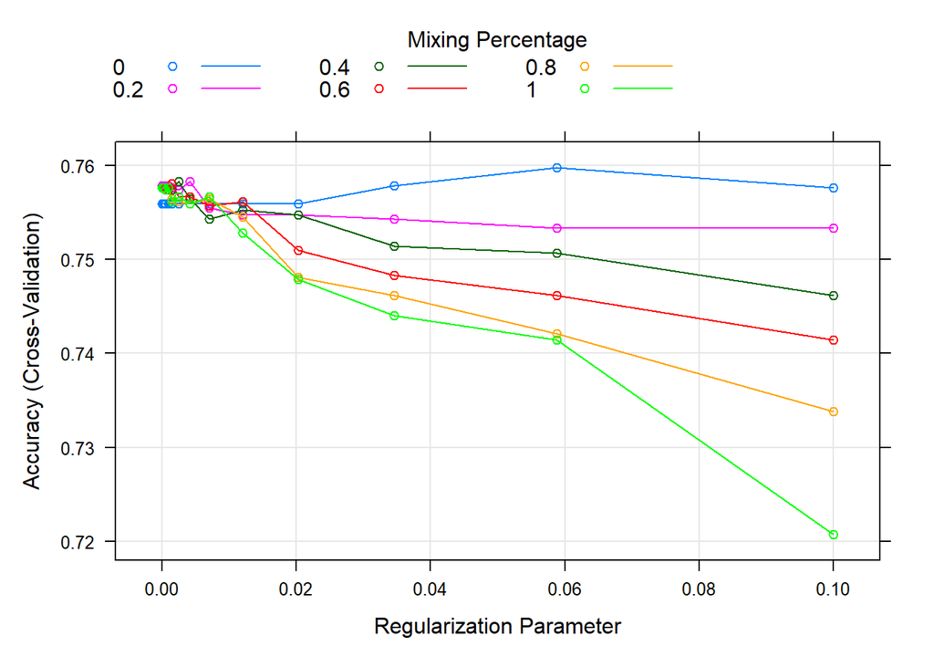

```r
plot(diabetes_elastic)
```

Let’s check variable importance:

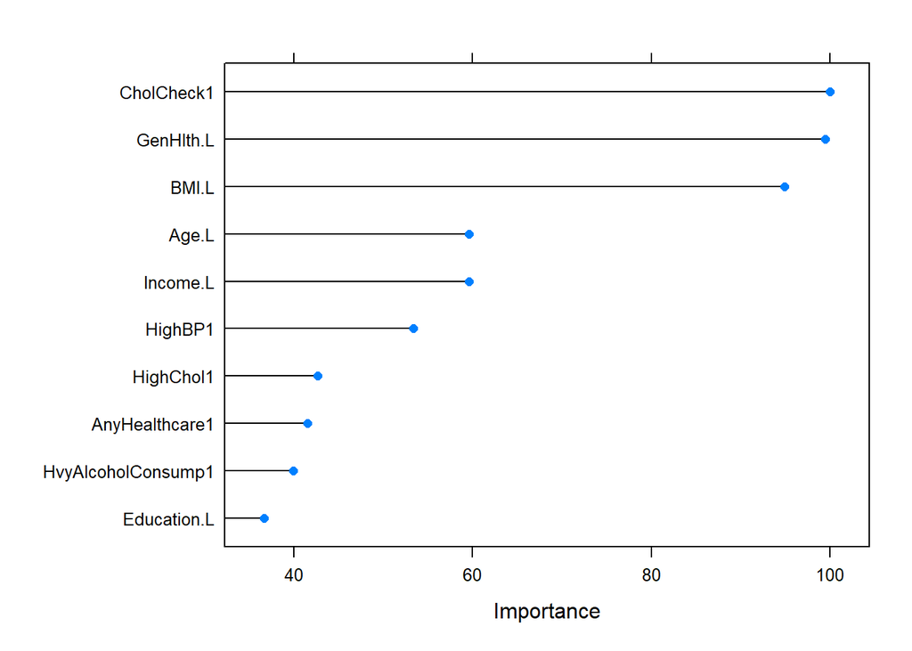

```r
var_diabetes_elastic <- varImp(diabetes_elastic)

plot(var_diabetes_elastic, top = 10)
```

Cholesterol check, general health , BMI as the most important variables.

Saving prediction for both subsets:

```r
forecast_elastic_train <-  predict(diabetes_elastic, diabetes_train, type = "prob")
forecast_elastic_test <-  predict(diabetes_elastic, diabetes_test, type = "prob")
```

## Neural net

```r
variables <- names(diabetes_train)
model.formula <- as.formula(paste("Outcome ~",
                                  paste(variables[!variables %in% "Outcome"],
                                        collapse = " + ")))
model.formula
```

```
## Outcome ~ HighBP + HighChol + CholCheck + BMI + Smoker + Stroke +
##     HeartDiseaseorAttack + PhysActivity + Fruits + Veggies +
##     HvyAlcoholConsump + AnyHealthcare + NoDocbcCost + GenHlth +
##     MentHlth + PhysHlth + DiffWalk + Sex + Age + Education +
##     Income
```

Neuralnet package requires that the numerical data is collected as data.frame or matrix:

```r
diabetes.train.mtx <-
  model.matrix(  diabetes_train,
                 object = model.formula)


dim(diabetes.train.mtx)
```

```
## [1] 4196   43
```

```r
colnames(diabetes.train.mtx)
```

```
##  [1] "(Intercept)"           "HighBP1"               "HighChol1"
##  [4] "CholCheck1"            "BMI.L"                 "BMI.Q"
##  [7] "BMI.C"                 "BMI^4"                 "BMI^5"
## [10] "Smoker1"               "Stroke1"               "HeartDiseaseorAttack1"
## [13] "PhysActivity1"         "Fruits1"               "Veggies1"
## [16] "HvyAlcoholConsump1"    "AnyHealthcare1"        "NoDocbcCost1"
## [19] "GenHlth.L"             "GenHlth.Q"             "GenHlth.C"
## [22] "GenHlth^4"             "MentHlth.L"            "MentHlth.Q"
## [25] "PhysHlth.L"            "PhysHlth.Q"            "DiffWalk1"
## [28] "Sex1"                  "Age.L"                 "Age.Q"
## [31] "Age.C"                 "Education.L"           "Education.Q"
## [34] "Education.C"           "Education^4"           "Education^5"
## [37] "Income.L"              "Income.Q"              "Income.C"
## [40] "Income^4"              "Income^5"              "Income^6"
## [43] "Income^7"
```

```r
colnames(diabetes.train.mtx) <- gsub(" ", "_",  colnames(diabetes.train.mtx))
colnames(diabetes.train.mtx) <- gsub(",", "_",  colnames(diabetes.train.mtx))
colnames(diabetes.train.mtx) <- gsub("/", "",   colnames(diabetes.train.mtx))
colnames(diabetes.train.mtx) <- gsub("-", "_",  colnames(diabetes.train.mtx))
colnames(diabetes.train.mtx) <- gsub("'", "",   colnames(diabetes.train.mtx))
colnames(diabetes.train.mtx) <- gsub("\\+", "", colnames(diabetes.train.mtx))
colnames(diabetes.train.mtx) <- gsub("\\^", "", colnames(diabetes.train.mtx))
colnames(diabetes.train.mtx)
```

```
##  [1] "(Intercept)"           "HighBP1"               "HighChol1"
##  [4] "CholCheck1"            "BMI.L"                 "BMI.Q"
##  [7] "BMI.C"                 "BMI4"                  "BMI5"
## [10] "Smoker1"               "Stroke1"               "HeartDiseaseorAttack1"
## [13] "PhysActivity1"         "Fruits1"               "Veggies1"
## [16] "HvyAlcoholConsump1"    "AnyHealthcare1"        "NoDocbcCost1"
## [19] "GenHlth.L"             "GenHlth.Q"             "GenHlth.C"
## [22] "GenHlth4"              "MentHlth.L"            "MentHlth.Q"
## [25] "PhysHlth.L"            "PhysHlth.Q"            "DiffWalk1"
## [28] "Sex1"                  "Age.L"                 "Age.Q"
## [31] "Age.C"                 "Education.L"           "Education.Q"
## [34] "Education.C"           "Education4"            "Education5"
## [37] "Income.L"              "Income.Q"              "Income.C"
## [40] "Income4"               "Income5"               "Income6"
## [43] "Income7"
```

```r
col_list <- paste(c(colnames(diabetes.train.mtx[, -1])), collapse = "+")
col_list <- paste(c("Outcome ~ ", col_list), collapse = "")
(model.formula2 <- formula(col_list))
```

```
## Outcome ~ HighBP1 + HighChol1 + CholCheck1 + BMI.L + BMI.Q +
##     BMI.C + BMI4 + BMI5 + Smoker1 + Stroke1 + HeartDiseaseorAttack1 +
##     PhysActivity1 + Fruits1 + Veggies1 + HvyAlcoholConsump1 +
##     AnyHealthcare1 + NoDocbcCost1 + GenHlth.L + GenHlth.Q + GenHlth.C +
##     GenHlth4 + MentHlth.L + MentHlth.Q + PhysHlth.L + PhysHlth.Q +
##     DiffWalk1 + Sex1 + Age.L + Age.Q + Age.C + Education.L +
##     Education.Q + Education.C + Education4 + Education5 + Income.L +
##     Income.Q + Income.C + Income4 + Income5 + Income6 + Income7
```

As it was hinted during labs, the number of hidden layers will be set to 2/3 of the input layers: taking all levels of the variables in my train dataset, i.e. 42, the number of neurons will be 28. The default algorithm will be used - Resilient Backpropogation (rprop+)

```r
diabetes.nn <-  data.frame(diabetes.train.mtx,
                           Outcome = as.numeric(diabetes_train$Outcome == 1)) %>%
  neuralnet(model.formula2,
            data = .,
            hidden = c(28),
            linear.output = FALSE,
            learningrate.limit = NULL,
            learningrate.factor = list(minus = 0.5, plus = 1.2),
            algorithm = "rprop+",
            threshold = 0.01)
```

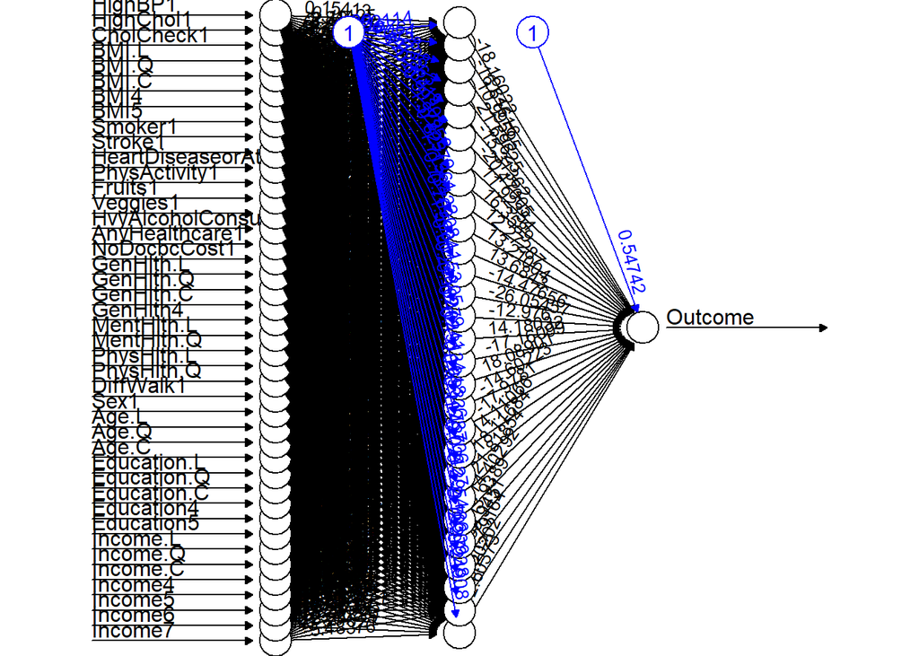

```r
plot(diabetes.nn, rep = "best")
```

Test subset must be also converted into a matrix:

```r
diabetes.test.mtx <-
  model.matrix(  diabetes_test,
                 object = model.formula)


colnames(diabetes.test.mtx) <- gsub(" ", "_",  colnames(diabetes.test.mtx))
colnames(diabetes.test.mtx) <- gsub(",", "_",  colnames(diabetes.test.mtx))
colnames(diabetes.test.mtx) <- gsub("/", "",   colnames(diabetes.test.mtx))
colnames(diabetes.test.mtx) <- gsub("-", "_",  colnames(diabetes.test.mtx))
colnames(diabetes.test.mtx) <- gsub("'", "",   colnames(diabetes.test.mtx))
colnames(diabetes.test.mtx) <- gsub("\\+", "", colnames(diabetes.test.mtx))
colnames(diabetes.test.mtx) <- gsub("\\^", "", colnames(diabetes.test.mtx))
colnames(diabetes.test.mtx)
```

```
##  [1] "(Intercept)"           "HighBP1"               "HighChol1"
##  [4] "CholCheck1"            "BMI.L"                 "BMI.Q"
##  [7] "BMI.C"                 "BMI4"                  "BMI5"
## [10] "Smoker1"               "Stroke1"               "HeartDiseaseorAttack1"
## [13] "PhysActivity1"         "Fruits1"               "Veggies1"
## [16] "HvyAlcoholConsump1"    "AnyHealthcare1"        "NoDocbcCost1"
## [19] "GenHlth.L"             "GenHlth.Q"             "GenHlth.C"
## [22] "GenHlth4"              "MentHlth.L"            "MentHlth.Q"
## [25] "PhysHlth.L"            "PhysHlth.Q"            "DiffWalk1"
## [28] "Sex1"                  "Age.L"                 "Age.Q"
## [31] "Age.C"                 "Education.L"           "Education.Q"
## [34] "Education.C"           "Education4"            "Education5"
## [37] "Income.L"              "Income.Q"              "Income.C"
## [40] "Income4"               "Income5"               "Income6"
## [43] "Income7"
```

Checking prediction accuracy with compute() function:

```r
diabetes.pred.nn <- compute(diabetes.nn, diabetes.test.mtx[, -1])
```

## Classification tree

For some reason the program did not accept 1/0 as levels of the dependent variable for tree based models. Therefore I had to change the notation to YES/NO.

```r
diabetes_train$Outcome <- ifelse(diabetes_train$Outcome == 1, "Yes", "No")
diabetes_train$Outcome <- as.factor(diabetes_train$Outcome)


diabetes_test$Outcome <- ifelse(diabetes_test$Outcome == 1, "Yes", "No")
diabetes_test$Outcome <- as.factor(diabetes_test$Outcome)
```

As it was already mentioned in regression project, the advantage of decision tree its non-sensitiveness to outliers and easiness to interpret and visualize.

To use simple classification tree firstly, I will let the tree grow very big. Then using cross-validation process performed within rpart function, we will obtain an optimal value of parameter cp - complexity cost function.

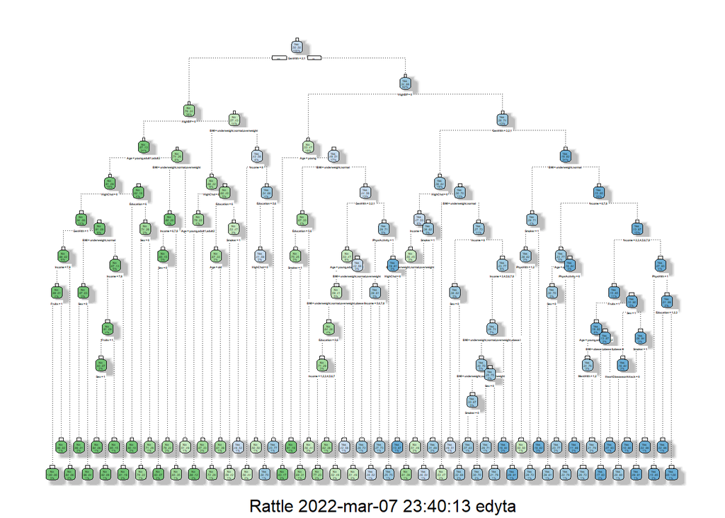

```r
library(rpart)
library(rpart.plot)
library(rattle)
diabetes_tree <-
  rpart(model.formula,
        data = diabetes_train,
        method = "class",
        minsplit = 84, # ~ 2% of the training set
        minbucket = 42, # ~ 1% of the training set
        maxdepth = 30, # default
        cp = -1)
fancyRpartPlot(diabetes_tree)
```

```r
printcp(diabetes_tree)
```

```
##
## Classification tree:
## rpart(formula = model.formula, data = diabetes_train, method = "class",
##     minsplit = 84, minbucket = 42, maxdepth = 30, cp = -1)
##
## Variables actually used in tree construction:
##  [1] Age                  BMI                  Education
##  [4] Fruits               GenHlth              HeartDiseaseorAttack
##  [7] HighBP               HighChol             Income
## [10] MentHlth             PhysActivity         PhysHlth
## [13] Sex                  Smoker
##
## Root node error: 2096/4196 = 0.49952
##
## n= 4196
##
##             CP nsplit rel error  xerror     xstd
## 1   0.39169847      0   1.00000 1.03006 0.015446
## 2   0.02242366      1   0.60830 0.60830 0.014214
## 3   0.01645992      2   0.58588 0.59542 0.014127
## 4   0.01001908      4   0.55296 0.57013 0.013948
## 5   0.00906489      5   0.54294 0.56632 0.013920
## 6   0.00858779      7   0.52481 0.56584 0.013916
## 7   0.00524809      8   0.51622 0.54389 0.013747
## 8   0.00429389      9   0.51097 0.54342 0.013744
## 9   0.00222646     10   0.50668 0.53674 0.013690
## 10  0.00190840     13   0.50000 0.54246 0.013736
## 11  0.00047710     14   0.49809 0.54771 0.013777
## 12  0.00031807     15   0.49761 0.55534 0.013837
## 13  0.00000000     18   0.49666 0.55773 0.013855
## 14 -1.00000000     70   0.49666 0.55773 0.013855
```

The model has a vital feature to select more important variables. As we may see, out of all 21 predictors, 14 were used.

Now I will build a model once again using optimal value of cp parameter.

[figure not shown]

```r
opt <- which.min(diabetes_tree$cptable[, "xerror"])
cp <- diabetes_tree$cptable[opt, "CP"]

diabetes_tree_OPT <-
  prune(diabetes_tree, cp = cp)
fancyRpartPlot(diabetes_tree_OPT)
```

```r
forecast_tree_train <-  as.data.frame(predict(diabetes_tree_OPT, diabetes_train, type = "prob"))
forecast_tree_test <-  as.data.frame(predict(diabetes_tree_OPT, diabetes_test, type = "prob"))
```

## Random forest

Random forests help to reduce tree correlation by introducing more randomness into the tree-growing process. More specifically, for every single decision tree from the forest, the trained data is bootstrapped from the original training dataset. As it was proved during labs, in a process of bootstrapping the sample, ca. 30% of the dataset is rejected. This 30% of data may be used then to prove the quality of the model, i.e out-of-bag error (“oob”)

Moreover for every single regression tree not all independent variables are used, but its subset. The number of chosen variables must be found using cross-validation. In my model I will try to check number of independent variables between 4 and 15. Using train() ficntion to build the model we can also tune minimum node size.

```r
set.seed(123456)
parameters_ranger <-
  expand.grid(mtry = 4:15,
              splitrule = c("gini"),
              min.node.size = c(20, 50, 70, 90))

ctrl_cv10 <- trainControl(method = "cv",
                         number =    10,
                         classProbs = T)


 diabetes.rf <-
    train(Outcome ~. ,
          data = diabetes_train,
          method = "ranger",
          num.trees = 500,
          num.threads = 3,
          importance = "impurity",
          tuneGrid = parameters_ranger,
          trControl = ctrl_cv10)


  diabetes.rf
```

```
## Random Forest
##
## 4196 samples
##   21 predictor
##    2 classes: 'No', 'Yes'
##
## No pre-processing
## Resampling: Cross-Validated (10 fold)
## Summary of sample sizes: 3777, 3776, 3776, 3776, 3777, 3776, ...
## Resampling results across tuning parameters:
##
##   mtry  min.node.size  Accuracy   Kappa
##    4    20             0.7452426  0.4904472
##    4    50             0.7502478  0.5004611
##    4    70             0.7483390  0.4966411
```

[output cut: 50 more lines]

Plotting changes if accuracy with resepect to variables change:

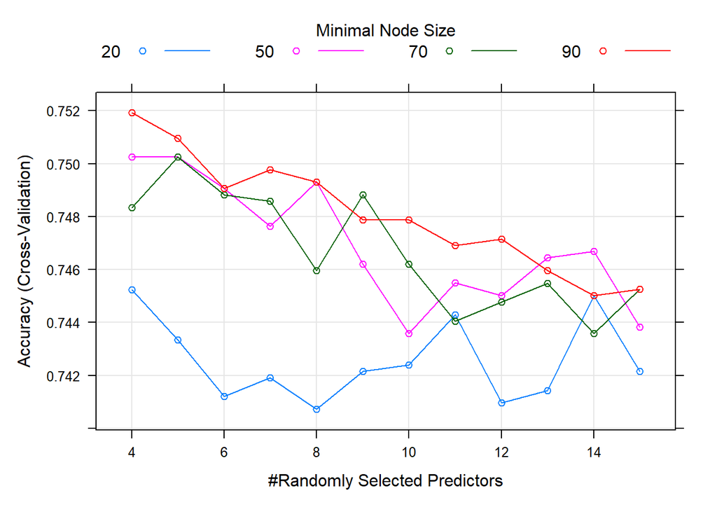

```r
plot(diabetes.rf)
```

```r
(tree1.importance <- varImp(diabetes.rf))
```

```
## ranger variable importance
##
##   only 20 most important variables shown (out of 42)
##
##                       Overall
## GenHlth.L             100.000
## HighBP1                79.688
## HighChol1              40.749
## GenHlth.C              38.123
## BMI.L                  33.030
## GenHlth^4              32.123
## Age.L                  31.563
## Income.L               31.302
## DiffWalk1              30.780
## BMI.C                  18.689
## Income.Q               17.509
## GenHlth.Q              17.140
## BMI^4                  16.784
## HeartDiseaseorAttack1  15.308
## BMI.Q                  10.073
## PhysHlth.L              9.091
## Education.L             8.736
## Age.C                   8.248
## Education.Q             7.043
## Income^4                6.935
```

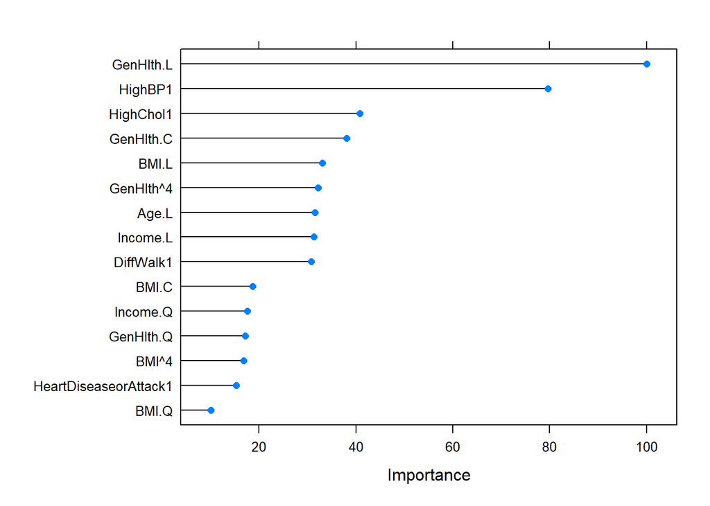

```r
plot(tree1.importance, top = 15)
```

General health, high blood and cholesterol are the most important variables.

Saving predictions…:

```r
forecast_rf_train <-  predict(diabetes.rf, diabetes_train, type = "prob")
forecast_rf_test <-  predict(diabetes.rf, diabetes_test, type = "prob")
```

# Conclusion - comparing quality measures using ROC/AUC

```r
library(pROC)


colnames(forecast_elastic_train)  <- c("No", "Yes")

ROC.elastic_train <- roc(as.numeric(diabetes_train$Outcome),
                       as.numeric(forecast_elastic_train$Yes))

colnames(forecast_elastic_test)  <- c("No", "Yes")

ROC.elastic_test <- roc(as.numeric(diabetes_test$Outcome),
                       as.numeric(forecast_elastic_test$Yes))


ROC.tree_train <- roc(as.numeric(diabetes_train$Outcome),
                       as.numeric(forecast_tree_train$Yes))

ROC.tree_test <- roc(as.numeric(diabetes_test$Outcome),
                       as.numeric(forecast_tree_test$Yes))


ROC.rf_train <- roc(as.numeric(diabetes_train$Outcome),
                       as.numeric(forecast_rf_train$Yes))

ROC.rf_test <- roc(as.numeric(diabetes_test$Outcome),
                       as.numeric(forecast_rf_test$Yes))

ROC.nn_test <- roc(as.numeric(diabetes_test$Outcome),
                       as.numeric(diabetes.pred.nn$net.result))
```

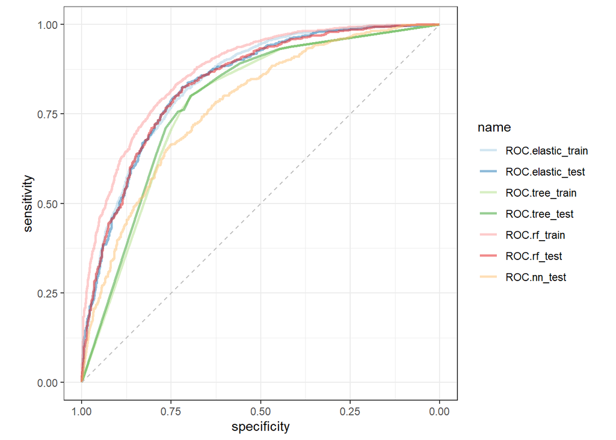

```r
list(
  ROC.elastic_train = ROC.elastic_train,
  ROC.elastic_test = ROC.elastic_test,
  ROC.tree_train = ROC.tree_train,
  ROC.tree_test  = ROC.tree_test,
  ROC.rf_train = ROC.rf_train,
  ROC.rf_test = ROC.rf_test,
  ROC.nn_test = ROC.nn_test
) %>%
  pROC::ggroc(alpha = 0.5, linetype = 1, size = 1) +
  geom_segment(aes(x = 1, xend = 0, y = 0, yend = 1),
               color = "grey",
               linetype = "dashed")   +
  theme_bw() + coord_fixed() +
  scale_color_brewer(palette = "Paired")
```

```r
auc(ROC.elastic_train)
```

```
## Area under the curve: 0.841
```

```r
auc(ROC.elastic_test)
```

```
## Area under the curve: 0.8371
```

```r
auc(ROC.tree_train)
```

```
## Area under the curve: 0.7792
```

```r
auc(ROC.tree_test)
```

```
## Area under the curve: 0.7868
```

```r
auc(ROC.rf_train)
```

```
## Area under the curve: 0.87
```

```r
auc(ROC.rf_test)
```

```
## Area under the curve: 0.8365
```

```r
auc(ROC.nn_test)
```

```
## Area under the curve: 0.773
```

The worst one performed neural network. This is because the number of hidden layers and neurons was chosen solely based on rules of thumb without any cross validation.

References:

Source of the dataset: https://www.kaggle.com/alexteboul/diabetes-health-indicators-dataset?select=diabetes_binary_health_indicators_BRFSS2015.csv

https://towardsdatascience.com/l1-and-l2-regularization-methods-ce25e7fc831c